# Hearthstone Deck Data Analysis

Xinlin Zhang

Data: History of Hearthstone: 346,242 decks posted by players at Hearthpwn from 2013 to 2017. https://www.kaggle.com/romainvincent/history-of-hearthstone

```r
library(sqldf)
library(ggplot2)
library(lubridate)
data <- read.csv("~/Desktop/Blizzard/history-of-hearthstone/data.csv", stringsAsFactors=FALSE)
```

### Question: What are the performances of decks posted by players?

##### (1) What is the number of decks by year?

##### (2) What’s the relationship between dust cost and the popularity of decks? What are the ratings by deck class over time?

##### (3) What is the average dust cost by deck class?

##### (4) What are the most popular cards for different deck classes?

### 1. Key Findings

##### (1) The number of uploaded decks had steady growth from 2013 to 2016. However, the number varied greatly in different formats (standard and wild). 2015 had the lowest number of uploaded decks in the standard format but the highest number in the wild format.

##### (2) There is a weak relationship between the dust cost and the popularity of decks. In the standard format, class “Rogue” had the most ratings in 2013. The ratings for class “Warrior” outperformed other classes from mid-2014 to 2016. In the wild format, ratings decreased from 2014 to 2015 and then stabilized.

##### (3) Except “Warrior”, deck classes cost more dust in the standard format than in the wild format. On average, class “Hunter” costs the least dust.

##### (4) Top 5 most popular cards for “Mage”, “Priest” and “Rogue” in the standard format are similar to those in the wild format.

### 2. Number of Decks by Year

##### The number of uploaded decks increased over year.

##### (Not considering the number in 2017 since data is only available before February 2017.)

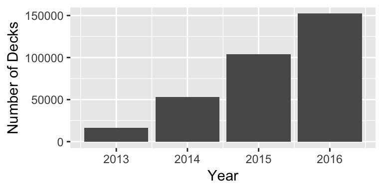

```r
data$year<-year(as.POSIXct(data$date))
ggplot(sqldf('select count(deck_id) as number, year from data where year !=2017 group by year'),aes(year,number)) + geom_bar(stat = "identity")+ ylab("Number of Decks")+ xlab("Year")
```

##### In the standard format, the number of uploaded decks had a rocket increase in 2016.

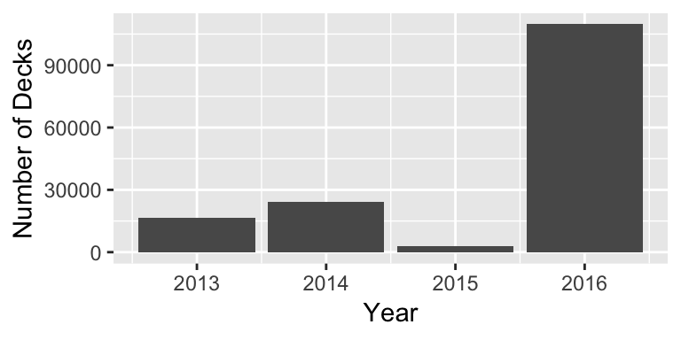

```r
standard_deck <- data[data$deck_format=='S',]
standard_deck$year<-year(as.POSIXct(standard_deck$date))
sdeck<-sqldf('select count(deck_id) as number, year from standard_deck where year != 2017 group by year')
ggplot(sdeck,aes(year,number)) + geom_bar(stat = "identity")+ ylab("Number of Decks")+ xlab("Year")
```

##### In the wild format, the number of uploaded decks had a drastic increase in 2015 and decreased in 2016.

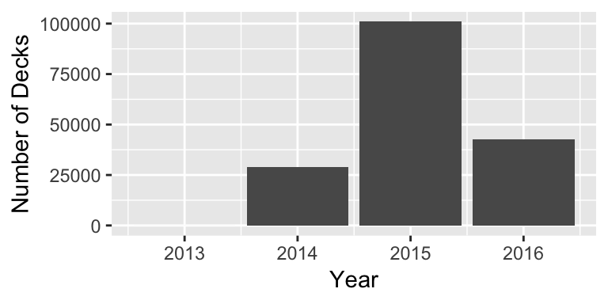

```r
wild_deck <- data[data$deck_format=='W',]
wild_deck$year<-year(as.POSIXct(wild_deck$date))
wdeck<-sqldf('select count(deck_id) as number, year from wild_deck where year != 2017 group by year')
ggplot(wdeck,aes(year,number)) + geom_bar(stat = "identity")+ ylab("Number of Decks")+ xlab("Year")
```

### 3. Ratings by Deck Class Over Time

##### There is a weak relationship between the dust cost and the popularity of decks.

```r
summary(lm(rating~craft_cost, data=standard_deck))
```

```
##
## Call:
## lm(formula = rating ~ craft_cost, data = standard_deck)
##
## Residuals:
##     Min      1Q  Median      3Q     Max
##   -2.38   -1.37   -1.36   -1.34 1866.64
##
## Coefficients:
##               Estimate Std. Error t value Pr(>|t|)
## (Intercept)  2.378e+00  8.434e-02   28.20   <2e-16 ***
## craft_cost  -3.349e-06  1.154e-05   -0.29    0.772
## ---
## Signif. codes:  0 '***' 0.001 '**' 0.01 '*' 0.05 '.' 0.1 ' ' 1
##
## Residual standard error: 19.78 on 170784 degrees of freedom
## Multiple R-squared:  4.934e-07,  Adjusted R-squared:  -5.362e-06
## F-statistic: 0.08426 on 1 and 170784 DF,  p-value: 0.7716
```

```r
summary(lm(rating~craft_cost, data=wild_deck))
```

```
##
## Call:
## lm(formula = rating ~ craft_cost, data = wild_deck)
##
## Residuals:
##    Min     1Q Median     3Q    Max
##   -3.2   -2.1   -2.0   -1.8 4013.3
##
## Coefficients:
##               Estimate Std. Error t value Pr(>|t|)
## (Intercept)  3.206e+00  1.012e-01  31.668   <2e-16 ***
## craft_cost  -3.760e-05  1.575e-05  -2.387    0.017 *
## ---
## Signif. codes:  0 '***' 0.001 '**' 0.01 '*' 0.05 '.' 0.1 ' ' 1
##
## Residual standard error: 24.17 on 175444 degrees of freedom
## Multiple R-squared:  3.247e-05,  Adjusted R-squared:  2.677e-05
## F-statistic: 5.696 on 1 and 175444 DF,  p-value: 0.017
```

##### Standard format: Rogue had the most ratings in 2013 but went all the way to bottom in the following one year. Ratings of class ‘Warrior’ are higher than that of other classes between mid 2014 and 2016. After 2016, all deck classes equalized.

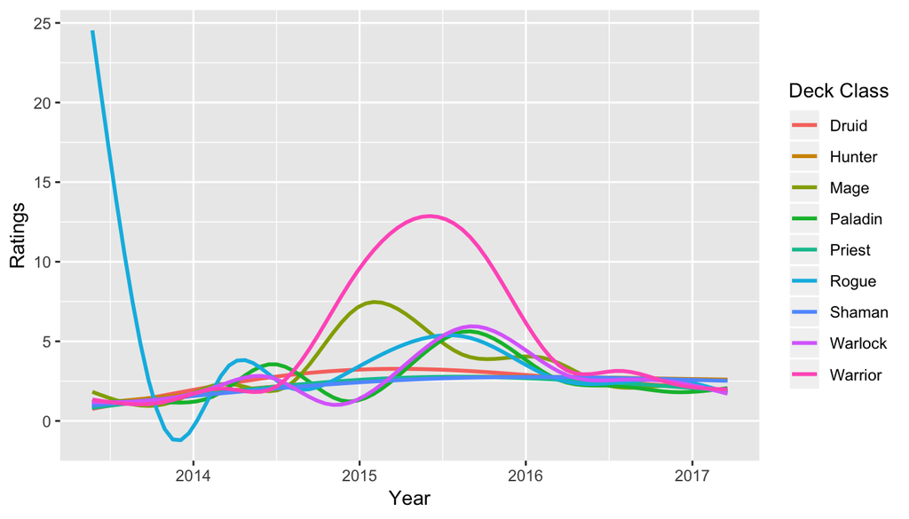

```r
standard_deck <- data[data$deck_format=='S',]
standard_deck$date <- as.POSIXct(standard_deck$date)
ggplot(standard_deck, aes(date, rating, col=deck_class)) + geom_smooth(se=F) + ylab("Ratings")+ xlab("Year") + labs(col="Deck Class")
```

##### Wild format: Apart from Paladin and Druid, other deck classes had the highest ratings when released and decreased in the following one year. Ratings converged after 2015.

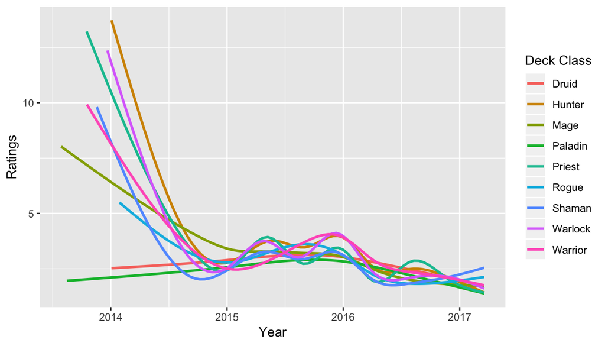

```r
wild_deck <- data[data$deck_format=='W',]
wild_deck$date <- as.POSIXct(wild_deck $date)
ggplot(wild_deck, aes(date, rating, col=deck_class)) + geom_smooth(se=F) + ylab("Ratings")+ xlab("Year") + labs(col="Deck Class")
```

### 4. Average Dust Cost by Deck Class

##### Except class “Warrior”, average dust cost is larger in standard format than in wild format. Mean craft cost for hunter is the smallest.

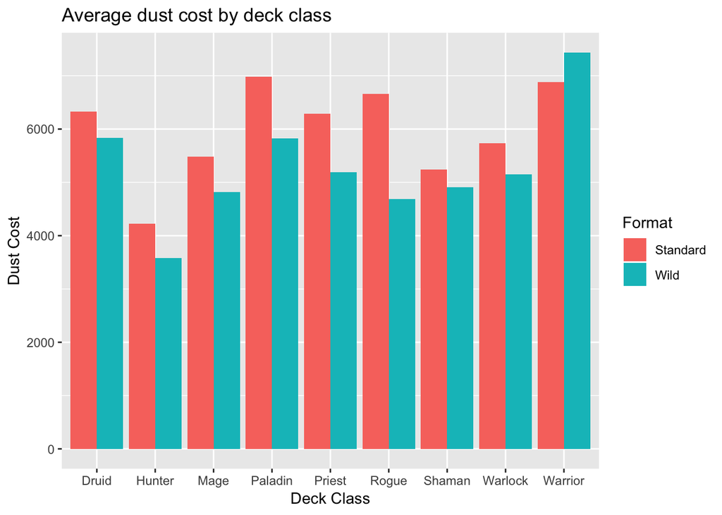

```r
savg<-sqldf('select avg(craft_cost) as Standard, deck_class from standard_deck group by deck_class')

wavg<-sqldf('select avg(craft_cost) as Wild, deck_class from wild_deck group by deck_class')
avgcost<-merge(savg,wavg)
library(reshape2)
cost_class<-melt(avgcost,id.vars='deck_class',variable.name="Format",value.name="cost")
ggplot(cost_class,aes(deck_class,cost,fill=Format))+geom_bar(stat='identity',position='dodge')+
  ggtitle("Average dust cost by deck class")+ ylab("Dust Cost")+ xlab("Deck Class")
```

### 5. Most Popular Cards for Different Deck Class

#### (1) Standard Format

##### Druid

```r
s_druid<-subset(standard_deck, deck_class=="Druid")
s_druid_card<-as.data.frame(table(as.vector(as.matrix(s_druid[12:41]))))
colnames(s_druid_card)<-c("Card_number","Freq")
s_druid_card<-s_druid_card[order(s_druid_card[,2],decreasing=T),]
s_druid_card[1:5,]
```

```
##     Card_number  Freq
## 9            64 35292
## 31          254 34735
## 17          137 32847
## 157        1124 24013
## 285       38319 20912
```

##### Hunter

```r
s_hunter<-subset(standard_deck, deck_class=="Hunter")
s_hunter_card<-as.data.frame(table(as.vector(as.matrix(s_hunter[12:41]))))
s_hunter_card<-s_hunter_card[order(s_hunter_card[,2],decreasing=T),]
s_hunter_card[1:5,]
```

```
##     Var1  Freq
## 50   437 24409
## 31   296 22449
## 164 1261 18760
## 180 1662 17797
## 163 1243 17763
```

##### Mage

```r
s_mage<-subset(standard_deck, deck_class=="Mage")
s_mage_card<-as.data.frame(table(as.vector(as.matrix(s_mage[12:41]))))
s_mage_card<-s_mage_card[order(s_mage_card[,2],decreasing=T),]
s_mage_card[1:5,]
```

```
##     Var1  Freq
## 93   662 31882
## 35   315 30621
## 71   555 27184
## 46   405 19952
## 143 1004 19540
```

##### Paladin

```r
s_paladin<-subset(standard_deck, deck_class=="Paladin")
s_paladin_card<-as.data.frame(table(as.vector(as.matrix(s_paladin[12:41]))))
s_paladin_card<-s_paladin_card[order(s_paladin_card[,2],decreasing=T),]
s_paladin_card[1:5,]
```

```
##     Var1  Freq
## 124  847 26981
## 63   476 26443
## 109  756 19527
## 166 1167 19024
## 283 2889 12383
```

##### Priest

```r
s_priest<-subset(standard_deck, deck_class=="Priest")
s_priest_card<-as.data.frame(table(as.vector(as.matrix(s_priest[12:41]))))
s_priest_card<-s_priest_card[order(s_priest_card[,2],decreasing=T),]
s_priest_card[1:5,]
```

```
##     Var1  Freq
## 78   613 31509
## 156 1363 30862
## 160 1367 25827
## 168 1650 24794
## 114  841 23689
```

##### Rogue

```r
s_rogue<-subset(standard_deck, deck_class=="Rogue")
s_rogue_card<-as.data.frame(table(as.vector(as.matrix(s_rogue[12:41]))))
s_rogue_card<-s_rogue_card[order(s_rogue_card[,2],decreasing=T),]
s_rogue_card[1:5,]
```

```
##     Var1  Freq
## 126  904 32165
## 17   180 31853
## 153 1117 23583
## 90   667 22889
## 60   461 22522
```

##### Shaman

```r
s_shaman<-subset(standard_deck, deck_class=="Shaman")
s_shaman_card<-as.data.frame(table(as.vector(as.matrix(s_shaman[12:41]))))
s_shaman_card<-s_shaman_card[order(s_shaman_card[,2],decreasing=T),]
s_shaman_card[1:5,]
```

```
##     Var1  Freq
## 111  766 28028
## 85   629 25107
## 28   238 22532
## 149 1008 22431
## 63   505 21704
```

##### Warlock

```r
s_warlock<-subset(standard_deck, deck_class=="Warlock")
s_warlock_card<-as.data.frame(table(as.vector(as.matrix(s_warlock[12:41]))))
s_warlock_card<-s_warlock_card[order(s_warlock_card[,2],decreasing=T),]
s_warlock_card[1:5,]
```

```
##     Var1  Freq
## 7     48 17659
## 114  846 17012
## 102  763 16597
## 260 2895 16169
## 151 1090 14967
```

##### Warrior

```r
s_warrior<-subset(standard_deck, deck_class=="Warrior")
s_warrior_card<-as.data.frame(table(as.vector(as.matrix(s_warrior[12:41]))))
s_warrior_card<-s_warrior_card[order(s_warrior_card[,2],decreasing=T),]
s_warrior_card[1:5,]
```

```
##      Var1  Freq
## 47    401 32981
## 113   785 27187
## 153  1074 18149
## 147  1023 17595
## 293 38530 16583
```

##### Most popular cards in the standard format:

```r
s_popular_cards<-cbind(s_druid_card[1:5,1],s_hunter_card[1:5,1],s_mage_card[1:5,1],s_paladin_card[1:5,1],s_priest_card[1:5,1],s_rogue_card[1:5,1],s_shaman_card[1:5,1],s_warlock_card[1:5,1],s_warrior_card[1:5,1])
colnames(s_popular_cards)<-c('Druid','Hunter','Mage','Paladin','Priest','Rogue','Shaman','Warlock','Warrior')
s_popular_cards
```

```
##      Druid Hunter Mage Paladin Priest Rogue Shaman Warlock Warrior
## [1,]     9     50   93     124     78   126    111       7      47
## [2,]    31     31   35      63    156    17     85     114     113
## [3,]    17    164   71     109    160   153     28     102     153
## [4,]   157    180   46     166    168    90    149     260     147
## [5,]   285    163  143     283    114    60     63     151     293
```

#### (2) Wild Format

##### Druid

```r
w_druid<-subset(wild_deck, deck_class=="Druid")
w_druid_card<-as.data.frame(table(as.vector(as.matrix(w_druid[12:41]))))
colnames(w_druid_card)<-c("Card_number","Freq")
w_druid_card<-w_druid_card[order(w_druid_card[,2],decreasing=T),]
w_druid_card[1:5,]
```

```
##     Card_number  Freq
## 8            64 28912
## 30          254 28429
## 16          137 24875
## 79          601 23685
## 359       38319 20980
```

##### Hunter

```r
w_hunter<-subset(wild_deck, deck_class=="Hunter")
w_hunter_card<-as.data.frame(table(as.vector(as.matrix(w_hunter[12:41]))))
w_hunter_card<-w_hunter_card[order(w_hunter_card[,2],decreasing=T),]
w_hunter_card[1:5,]
```

```
##     Var1  Freq
## 48   437 24152
## 30   296 22021
## 175 1662 19974
## 159 1243 19683
## 184 1783 18752
```

##### Mage

```r
w_mage<-subset(wild_deck, deck_class=="Mage")
w_mage_card<-as.data.frame(table(as.vector(as.matrix(w_mage[12:41]))))
w_mage_card<-w_mage_card[order(w_mage_card[,2],decreasing=T),]
w_mage_card[1:5,]
```

```
##     Var1  Freq
## 93   662 40438
## 35   315 35632
## 71   555 26148
## 184 1783 25273
## 143 1004 22742
```

##### Paladin

```r
w_paladin<-subset(wild_deck, deck_class=="Paladin")
w_paladin_card<-as.data.frame(table(as.vector(as.matrix(w_paladin[12:41]))))
w_paladin_card<-w_paladin_card[order(w_paladin_card[,2],decreasing=T),]
w_paladin_card[1:5,]
```

```
##     Var1  Freq
## 58   476 34840
## 117  847 33132
## 209 2026 30346
## 212 2029 27732
## 157 1167 22558
```

##### Priest

```r
w_priest<-subset(wild_deck, deck_class=="Priest")
w_priest_card<-as.data.frame(table(as.vector(as.matrix(w_priest[12:41]))))
w_priest_card<-w_priest_card[order(w_priest_card[,2],decreasing=T),]
w_priest_card[1:5,]
```

```
##     Var1  Freq
## 78   613 34541
## 168 1650 32840
## 114  841 27728
## 156 1363 27586
## 155 1362 20015
```

##### Rogue

```r
w_rogue<-subset(wild_deck, deck_class=="Rogue")
w_rogue_card<-as.data.frame(table(as.vector(as.matrix(w_rogue[12:41]))))
w_rogue_card<-w_rogue_card[order(w_rogue_card[,2],decreasing=T),]
w_rogue_card[1:5,]
```

```
##     Var1  Freq
## 126  904 25286
## 17   180 23930
## 59   459 21846
## 153 1117 18143
## 60   461 17817
```

##### Shaman

```r
w_shaman<-subset(wild_deck, deck_class=="Shaman")
w_shaman_card<-as.data.frame(table(as.vector(as.matrix(w_shaman[12:41]))))
w_shaman_card<-w_shaman_card[order(w_shaman_card[,2],decreasing=T),]
w_shaman_card[1:5,]
```

```
##     Var1  Freq
## 108  766 22748
## 82   629 21504
## 27   239 20517
## 145 1008 18687
## 22   189 18243
```

##### Warlock

```r
w_warlock<-subset(wild_deck, deck_class=="Warlock")
w_warlock_card<-as.data.frame(table(as.vector(as.matrix(w_warlock[12:41]))))
w_warlock_card<-w_warlock_card[order(w_warlock_card[,2],decreasing=T),]
w_warlock_card[1:5,]
```

```
##     Var1  Freq
## 100  763 20256
## 112  846 19562
## 7     48 18254
## 261 2093 17886
## 150 1092 16606
```

##### Warrior

```r
w_warrior<-subset(wild_deck, deck_class=="Warrior")
w_warrior_card<-as.data.frame(table(as.vector(as.matrix(w_warrior[12:41]))))
w_warrior_card<-w_warrior_card[order(w_warrior_card[,2],decreasing=T),]
w_warrior_card[1:5,]
```

```
##     Var1  Freq
## 45   401 28117
## 111  785 27623
## 195 1805 27223
## 174 1659 19334
## 76   596 19239
```

##### Most popular cards in the wild format:

```r
w_popular_cards<-cbind(w_druid_card[1:5,1],w_hunter_card[1:5,1],w_mage_card[1:5,1],w_paladin_card[1:5,1],w_priest_card[1:5,1],w_rogue_card[1:5,1],w_shaman_card[1:5,1],w_warlock_card[1:5,1],w_warrior_card[1:5,1])
colnames(w_popular_cards)<-c('Druid','Hunter','Mage','Paladin','Priest','Rogue','Shaman','Warlock','Warrior')
w_popular_cards
```

```
##      Druid Hunter Mage Paladin Priest Rogue Shaman Warlock Warrior
## [1,]     8     48   93      58     78   126    108     100      45
## [2,]    30     30   35     117    168    17     82     112     111
## [3,]    16    175   71     209    114    59     27       7     195
## [4,]    79    159  184     212    156   153    145     261     174
## [5,]   359    184  143     157    155    60     22     150      76
```

### Appendix: Data Description

##### Actual Hearthstone deck records. Each record features :

```r
library(readxl)
Description <- read_excel("~/Desktop/Description.xlsx")
Description
```

```
## # A tibble: 12 x 2
##    Feature           Description
##    <chr>             <chr>
##  1 date (str)        the date of publication (or last update) of the deck.
##  2 user (str)        the user who uploaded the deck.
##  3 deck_class (str)  one of the nine character class in Hearthstone (Drui…
##  4 deck_archetype (… the theme of deck labelled by the user (Aggro Druid,…
##  5 deck_format (str) "the game format of the deck on the day data was rec…
##  6 deck_set (str)    the latest expansion published prior the deck public…
##  7 deck_id (int)     the ID of the deck.
##  8 deck_type (str)   the type of the deck labelled by the user.
##  9 rating (int)      the number of upvotes received by that deck.
## 10 title (str)       the name of the deck.
## 11 craft_cost (int)  the amount of dust (in-game craft material) required…
## 12 cards (list)      a list of 30 card ids. Each ID can be mapped to the …
```